# Push-Up Journey

## Road to strong man.

This is a analysis on my Push-up journey where every time I completed a set of push-ups, I logged it with a Google survey and published it into a google spreadsheet.

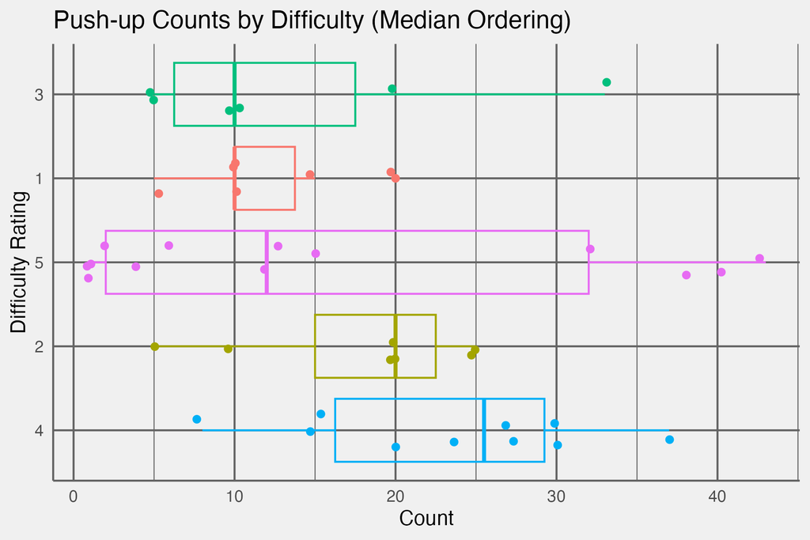

The hardest difficulty median reps completed is actually in the middle significantly lower than difficulty 2. When we look at the variation however, difficulty 5 has much more variation compared to the others. This is largely due to the variant of pus-hup where the harder variants become much harder much quicker.

## Have I improved over time?

Looking at all the data, it seems that yes, I have improved in the second week.

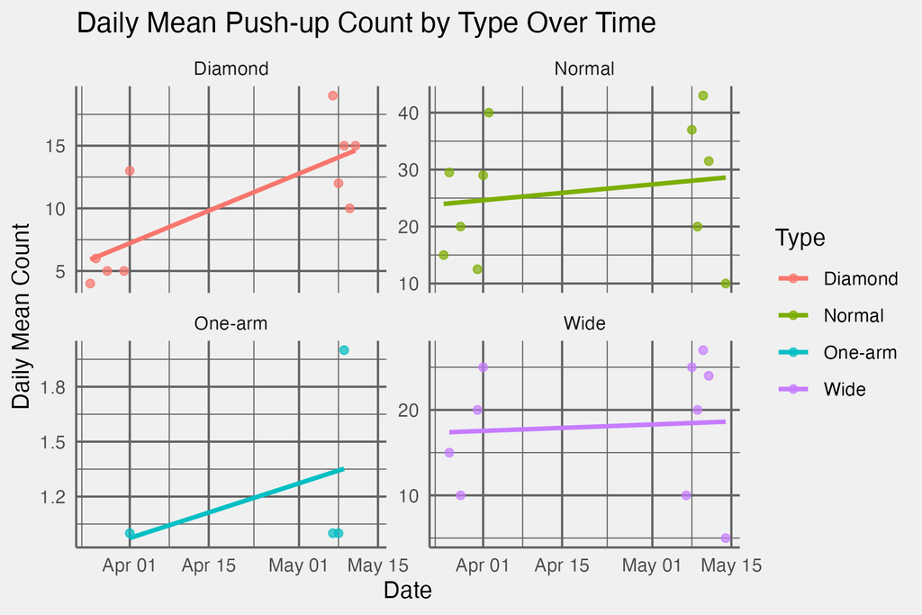

## Looking a bit closer

Compared to the overall data, it seems that the last week, I had gotten worse?

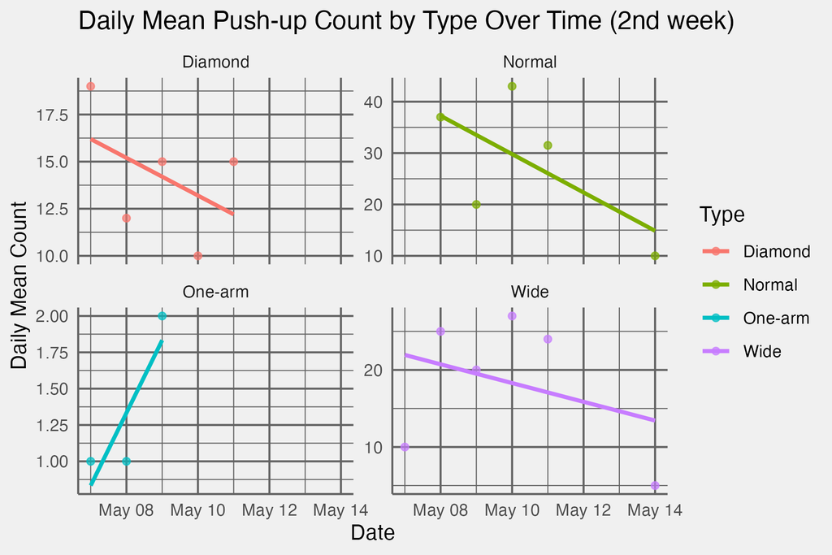

Looking at this data, we see that we actually got worse overtime in the last week. Data collection was actually going well at the start but during the week I had gotten sick so it became diffucult to complete more reps.

## Does the hour of the day matter?

The data appears to not really have a trend where I was quite consistent with the amount push-ups completed at any time of the day.

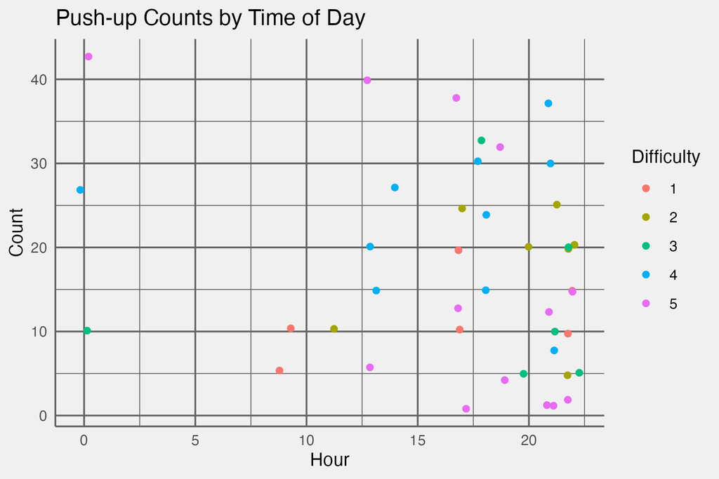

There doesn’t seem to be any data to suggest that if I do push-ups in the morning vs afternoon, I would be able to rep more.

## In Conclusion

From this experience, I was able to learn that I need to complete more push-ups. Its as simple as that, to get better at push-ups I just need to do more push-ups and with proper form, I can do even more.

[figure not shown]